# **Cars4U Project: Vanika Hans**

## Section 4: Observations Before Cleaning the Dataset

#### Check the number of rows

```python
df.shape
```

```
(7253, 14)
```

#### Check the columns

```python
df.columns
```

```
Index(['S.No.', 'Name', 'Location', 'Year', 'Kilometers_Driven', 'Fuel_Type',
       'Transmission', 'Owner_Type', 'Mileage', 'Engine', 'Power', 'Seats',
       'New_Price', 'Price'],
      dtype='object')
```

#### Check For Missing Values in Each Column Type

```python
df.info()
```

```
<class 'pandas.core.frame.DataFrame'>
RangeIndex: 7253 entries, 0 to 7252
Data columns (total 14 columns):
 #   Column             Non-Null Count  Dtype
---  ------             --------------  -----
 0   S.No.              7253 non-null   int64
 1   Name               7253 non-null   object
 2   Location           7253 non-null   object
 3   Year               7253 non-null   int64
 4   Kilometers_Driven  7253 non-null   int64
 5   Fuel_Type          7253 non-null   object
 6   Transmission       7253 non-null   object
 7   Owner_Type         7253 non-null   object
 8   Mileage            7251 non-null   object
 9   Engine             7207 non-null   object
 10  Power              7207 non-null   object
 11  Seats              7200 non-null   float64
 12  New_Price          1006 non-null   object
 13  Price              6019 non-null   float64
dtypes: float64(2), int64(3), object(9)
memory usage: 793.4+ KB
```

#### Observation: There are 7253 rows and 14 columns

#### Looking at which columns have the most missing values

```python
df.isnull().sum().sort_values(ascending=False)
```

```
New_Price            6247
Price                1234
Seats                  53
Power                  46
Engine                 46
Mileage                 2
Owner_Type              0
Transmission            0
Fuel_Type               0
Kilometers_Driven       0
Year                    0
Location                0
Name                    0
S.No.                   0
dtype: int64
```

#### In summary, here's what stands out:

1. "Price" is the dependent variable, but also contains a large number of NaN values. These rows are not useful to us
2. Mileage contains units along with the numbers, and different units, as well (km/kg & kmpl). This needs to be cleaned up.
3. Engine also contains units "CC". This needs to be cleaned, too.
4. Power contains units.
5. There are a whole bunch of blanks for New_Price column, and this column contains Lakhs along with the units.
6. Model details can be simplified; we can just keep the Model and remove name of the car.
7. Missing values are present. Will need to clean this later on.

## Section 5a: Cleaning Up the Columns [PRICE]

#### Since Price is our dependent variable, we should delete the rows where Price is NaN, because rows without our dependent variable are useless.

```python
df['Price'].value_counts(dropna=False)
```

```
NaN      1234
4.50       88
5.50       84
3.50       82
4.25       73
         ...
11.96       1
5.76        1
24.99       1
42.75       1
25.51       1
Name: Price, Length: 1374, dtype: int64
```

```python
df = df[df['Price'].notna()]
df['Price'].value_counts(dropna=False)
df.info()
```

```
<class 'pandas.core.frame.DataFrame'>
Int64Index: 6019 entries, 0 to 6018
Data columns (total 14 columns):
 #   Column             Non-Null Count  Dtype
---  ------             --------------  -----
 0   S.No.              6019 non-null   int64
 1   Name               6019 non-null   object
 2   Location           6019 non-null   object
 3   Year               6019 non-null   int64
 4   Kilometers_Driven  6019 non-null   int64
 5   Fuel_Type          6019 non-null   object
 6   Transmission       6019 non-null   object
 7   Owner_Type         6019 non-null   object
 8   Mileage            6017 non-null   object
 9   Engine             5983 non-null   object
 10  Power              5983 non-null   object
 11  Seats              5977 non-null   float64
 12  New_Price          824 non-null    object
 13  Price              6019 non-null   float64
dtypes: float64(2), int64(3), object(9)
memory usage: 705.4+ KB
```

#### There are now 6019 rows. Let's see missing values now:

```python
df.isnull().sum().sort_values(ascending=False)
```

```
New_Price            5195
Seats                  42
Power                  36
Engine                 36
Mileage                 2
Price                   0
Owner_Type              0
Transmission            0
Fuel_Type               0
Kilometers_Driven       0
Year                    0
Location                0
Name                    0
S.No.                   0
dtype: int64
```

#### New_Price has a large amt of missing values; however, it might be interesting to keep this dataset to see how this compares to price. We will keep it as it is for now.

## Section 5b: Cleaning Up the Columns [NAME]

#### We need to strip the specific model out from the name and just keep the type of car. There may be some pattern here.

```python
def simplify_name(fn_input):
    """Strips off specific model name from name, ie Hyundai Sonata will become just Hyundai."""
    if isinstance(fn_input, str):
        splt = fn_input.split(" ")
        return str(splt[0])
    else:
        return np.nan

df['Name_Simplified'] = df['Name']
df['Name_Simplified'] = df['Name_Simplified'].apply(simplify_name)
df['Name_Simplified'] #check
```

```
0          Maruti
1         Hyundai
2           Honda
3          Maruti
4            Audi
          ...
6014       Maruti
6015      Hyundai
6016     Mahindra
6017       Maruti
6018    Chevrolet
Name: Name_Simplified, Length: 6019, dtype: object
```

#### Translate back to Name column and remove Name_Simplified

```python
df['Name'] = df['Name_Simplified']
df.drop(['Name_Simplified'],axis=1, inplace=True)
df.head()
```

|  | S.No. | Name | Location | Year | Kilometers_Driven | Fuel_Type | Transmission | Owner_Type | Mileage | Engine | Power | Seats | New_Price | Price |
| --- | --- | --- | --- | --- | --- | --- | --- | --- | --- | --- | --- | --- | --- | --- |
| 0 | 0 | Maruti | Mumbai | 2010 | 72000 | CNG | Manual | First | 26.6 km/kg | 998 CC | 58.16 bhp | 5.0 | NaN | 1.75 |
| 1 | 1 | Hyundai | Pune | 2015 | 41000 | Diesel | Manual | First | 19.67 kmpl | 1582 CC | 126.2 bhp | 5.0 | NaN | 12.50 |
| 2 | 2 | Honda | Chennai | 2011 | 46000 | Petrol | Manual | First | 18.2 kmpl | 1199 CC | 88.7 bhp | 5.0 | 8.61 Lakh | 4.50 |
| 3 | 3 | Maruti | Chennai | 2012 | 87000 | Diesel | Manual | First | 20.77 kmpl | 1248 CC | 88.76 bhp | 7.0 | NaN | 6.00 |
| 4 | 4 | Audi | Coimbatore | 2013 | 40670 | Diesel | Automatic | Second | 15.2 kmpl | 1968 CC | 140.8 bhp | 5.0 | NaN | 17.74 |

## Section 5c: Cleaning Up the Columns [MILEAGE]

#### Need to Clean Up Units for Mileage

```python
#Note that: 1 liter (l) = 1 kilogram (kg). Therefore, km/kg = kmpl. Kmpl means km per liter.
#So really these are the same measurement.

# Let us extract the units from all of the entries in the columns and:
# (1) make sure we're only dealing with km/kg vs kmpl
# (2) standardize units

def print_units(fn_input):
    """Returns the units of the mileage input from df."""
    if isinstance(fn_input, str):
        splt = fn_input.split(" ")
        return str(splt[1])
    else:
        return np.nan

df['Mileage_Units'] = df['Mileage']
df['Mileage_Units'] = df['Mileage_Units'].apply(print_units)
df['Mileage_Units'].value_counts(dropna=False)
```

```
kmpl     5951
km/kg      66
NaN         2
Name: Mileage_Units, dtype: int64
```

#### Extra step: Since the majority of units are in kmpl, let us convert the km/kg also to kmpl, and then drop the unit. This way, all the numbers are in the same unit before we drop the unit and just leave the number.

```python
def convert_mileage_units(fn_input):
    """Returns the units of the function input from df."""
    substring = "kg"
    if isinstance(fn_input, str):
        splt = fn_input.split(" ")
        if substring in splt[1]:
            splt[1]="kmpl"
            dummy_string = " ".join(splt)
            fn_input=str(dummy_string)
            fn_input = ''.join(fn_input)
            return fn_input
        else:
            fn_input = ''.join(fn_input)
            return fn_input
    else:
        return np.nan

df['Mileage_Units'] = df['Mileage'].apply(convert_mileage_units)
df.Mileage_Units.head() # check
```

```
0     26.6 kmpl
1    19.67 kmpl
2     18.2 kmpl
3    20.77 kmpl
4     15.2 kmpl
Name: Mileage_Units, dtype: object
```

#### Everything is in kmpl now. So we can drop units now!

```python
def drop_units(fn_input):
    """Drops units"""

    substring = "null"

    if isinstance(fn_input, str):
        if substring in fn_input: #ex/ if the word "null bhp" shows up
            fn_input = 0
            return float(fn_input)
        else:
            splt = fn_input.split(" ")
            fn_input = splt[0]
            return(float(fn_input))
    else:
        return np.nan

df['Mileage_Units'] = df['Mileage'].apply(drop_units)
df.head() # check
```

|  | S.No. | Name | Location | Year | Kilometers_Driven | Fuel_Type | Transmission | Owner_Type | Mileage | Engine | Power | Seats | New_Price | Price | Mileage_Units |
| --- | --- | --- | --- | --- | --- | --- | --- | --- | --- | --- | --- | --- | --- | --- | --- |
| 0 | 0 | Maruti | Mumbai | 2010 | 72000 | CNG | Manual | First | 26.6 km/kg | 998 CC | 58.16 bhp | 5.0 | NaN | 1.75 | 26.60 |
| 1 | 1 | Hyundai | Pune | 2015 | 41000 | Diesel | Manual | First | 19.67 kmpl | 1582 CC | 126.2 bhp | 5.0 | NaN | 12.50 | 19.67 |
| 2 | 2 | Honda | Chennai | 2011 | 46000 | Petrol | Manual | First | 18.2 kmpl | 1199 CC | 88.7 bhp | 5.0 | 8.61 Lakh | 4.50 | 18.20 |
| 3 | 3 | Maruti | Chennai | 2012 | 87000 | Diesel | Manual | First | 20.77 kmpl | 1248 CC | 88.76 bhp | 7.0 | NaN | 6.00 | 20.77 |
| 4 | 4 | Audi | Coimbatore | 2013 | 40670 | Diesel | Automatic | Second | 15.2 kmpl | 1968 CC | 140.8 bhp | 5.0 | NaN | 17.74 | 15.20 |

#### Since it looks okay, let's update the Mileage series and delete the "Mileage_Units" series

```python
df['Mileage'] = df['Mileage_Units']
df.drop(['Mileage_Units'],axis=1, inplace=True)
df.head() # to check!
### NOTE: we could programmatically check that the numbers are the same in both columns if we wanted to be more verbose.
### Will come back to this if more time
```

|  | S.No. | Name | Location | Year | Kilometers_Driven | Fuel_Type | Transmission | Owner_Type | Mileage | Engine | Power | Seats | New_Price | Price |
| --- | --- | --- | --- | --- | --- | --- | --- | --- | --- | --- | --- | --- | --- | --- |
| 0 | 0 | Maruti | Mumbai | 2010 | 72000 | CNG | Manual | First | 26.60 | 998 CC | 58.16 bhp | 5.0 | NaN | 1.75 |
| 1 | 1 | Hyundai | Pune | 2015 | 41000 | Diesel | Manual | First | 19.67 | 1582 CC | 126.2 bhp | 5.0 | NaN | 12.50 |
| 2 | 2 | Honda | Chennai | 2011 | 46000 | Petrol | Manual | First | 18.20 | 1199 CC | 88.7 bhp | 5.0 | 8.61 Lakh | 4.50 |
| 3 | 3 | Maruti | Chennai | 2012 | 87000 | Diesel | Manual | First | 20.77 | 1248 CC | 88.76 bhp | 7.0 | NaN | 6.00 |
| 4 | 4 | Audi | Coimbatore | 2013 | 40670 | Diesel | Automatic | Second | 15.20 | 1968 CC | 140.8 bhp | 5.0 | NaN | 17.74 |

## Section 5d: Cleaning Up the Columns [ENGINE]

#### We can follow a similar pattern for Engine. First make sure no more units exist besides "CC", and then remove the units

```python
df['Engine_Units'] = df['Engine'].apply(print_units)
df['Engine_Units'].value_counts(dropna=False)
```

```
CC     5983
NaN      36
Name: Engine_Units, dtype: int64
```

#### Only units in this column being used is CC. So we can drop.

```python
df['Engine_Units'] = df['Engine'].apply(drop_units)
df['Engine'] = df['Engine_Units']
df.drop(['Engine_Units'],axis=1, inplace=True)
df.head() # check
```

|  | S.No. | Name | Location | Year | Kilometers_Driven | Fuel_Type | Transmission | Owner_Type | Mileage | Engine | Power | Seats | New_Price | Price |
| --- | --- | --- | --- | --- | --- | --- | --- | --- | --- | --- | --- | --- | --- | --- |
| 0 | 0 | Maruti | Mumbai | 2010 | 72000 | CNG | Manual | First | 26.60 | 998.0 | 58.16 bhp | 5.0 | NaN | 1.75 |
| 1 | 1 | Hyundai | Pune | 2015 | 41000 | Diesel | Manual | First | 19.67 | 1582.0 | 126.2 bhp | 5.0 | NaN | 12.50 |
| 2 | 2 | Honda | Chennai | 2011 | 46000 | Petrol | Manual | First | 18.20 | 1199.0 | 88.7 bhp | 5.0 | 8.61 Lakh | 4.50 |
| 3 | 3 | Maruti | Chennai | 2012 | 87000 | Diesel | Manual | First | 20.77 | 1248.0 | 88.76 bhp | 7.0 | NaN | 6.00 |
| 4 | 4 | Audi | Coimbatore | 2013 | 40670 | Diesel | Automatic | Second | 15.20 | 1968.0 | 140.8 bhp | 5.0 | NaN | 17.74 |

## Section 5e: Cleaning Up the Columns [POWER]

#### Same process for Power

```python
df['Power_Units'] = df['Power'].apply(print_units)
df['Power_Units'].value_counts(dropna=False)
```

```
bhp    5983
NaN      36
Name: Power_Units, dtype: int64
```

#### Only units in this column being used is bhp. So we can drop.

```python
df['Power_Units'] = df['Power'].apply(drop_units)
df['Power'] = df['Power_Units']
df.drop(['Power_Units'],axis=1, inplace=True)
df.head() # check
```

|  | S.No. | Name | Location | Year | Kilometers_Driven | Fuel_Type | Transmission | Owner_Type | Mileage | Engine | Power | Seats | New_Price | Price |
| --- | --- | --- | --- | --- | --- | --- | --- | --- | --- | --- | --- | --- | --- | --- |
| 0 | 0 | Maruti | Mumbai | 2010 | 72000 | CNG | Manual | First | 26.60 | 998.0 | 58.16 | 5.0 | NaN | 1.75 |
| 1 | 1 | Hyundai | Pune | 2015 | 41000 | Diesel | Manual | First | 19.67 | 1582.0 | 126.20 | 5.0 | NaN | 12.50 |
| 2 | 2 | Honda | Chennai | 2011 | 46000 | Petrol | Manual | First | 18.20 | 1199.0 | 88.70 | 5.0 | 8.61 Lakh | 4.50 |
| 3 | 3 | Maruti | Chennai | 2012 | 87000 | Diesel | Manual | First | 20.77 | 1248.0 | 88.76 | 7.0 | NaN | 6.00 |
| 4 | 4 | Audi | Coimbatore | 2013 | 40670 | Diesel | Automatic | Second | 15.20 | 1968.0 | 140.80 | 5.0 | NaN | 17.74 |

## Section 5f: Cleaning Up the Columns [NEW_PRICE]

#### Follow same process as in section 5a-5c

```python
df['New_Price_Units'] = df['New_Price'].apply(print_units)
df['New_Price_Units'].value_counts(dropna=False)
```

```
NaN     5195
Lakh     807
Cr        17
Name: New_Price_Units, dtype: int64
```

#### Looks like it's not just Lakh; we've got a couple of rows in Crore. 1 Crore = 100 Lakhs, so if the row has a Crore, just multiple by 100 to be in Lakh

```python
def convert_cr_to_lakh(fn_input):
    """Converts cr to lakh, outputs string unit"""
    substring = "Cr"
    if isinstance(fn_input, str):
        splt = fn_input.split(" ")
        if substring in splt[1]:
            print("Before Conversion: ",fn_input)
            dummy = float(splt[0]) * 100
            splt[0]=str(dummy)
            splt[1]="Lakh"
            dummy_string = " ".join(splt)
            fn_input=str(dummy_string)
            fn_input = ''.join(fn_input)
            print("After Conversion: ",fn_input)
            return fn_input
        else:
            fn_input = ''.join(fn_input)
            return fn_input
    else:
        return np.nan

df['New_Price_Converted'] = df['New_Price'].apply(convert_cr_to_lakh)
# See prints for when function did conversion
```

```
Before Conversion:  1.28 Cr
After Conversion:  128.0 Lakh
Before Conversion:  1.04 Cr
After Conversion:  104.0 Lakh
Before Conversion:  1 Cr
After Conversion:  100.0 Lakh
Before Conversion:  1.04 Cr
After Conversion:  104.0 Lakh
Before Conversion:  1.39 Cr
After Conversion:  139.0 Lakh
Before Conversion:  1.02 Cr
After Conversion:  102.0 Lakh
Before Conversion:  1.4 Cr
After Conversion:  140.0 Lakh
Before Conversion:  1.06 Cr
After Conversion:  106.0 Lakh
Before Conversion:  1.27 Cr
After Conversion:  127.0 Lakh
Before Conversion:  1.13 Cr
After Conversion:  112.99999999999999 Lakh
Before Conversion:  1.36 Cr
After Conversion:  136.0 Lakh
Before Conversion:  1.66 Cr
After Conversion:  166.0 Lakh
Before Conversion:  1.6 Cr
After Conversion:  160.0 Lakh
Before Conversion:  1.28 Cr
After Conversion:  128.0 Lakh
Before Conversion:  2.3 Cr
After Conversion:  229.99999999999997 Lakh
Before Conversion:  1.71 Cr
After Conversion:  171.0 Lakh
Before Conversion:  1.39 Cr
After Conversion:  139.0 Lakh
```

```python
df["New_Price_Units"] = df["New_Price_Converted"].apply(print_units)
df['New_Price_Units'].value_counts(dropna=False)
```

```
NaN     5195
Lakh     824
Name: New_Price_Units, dtype: int64
```

#### It worked! Now, we can drop the units and drop the extra series (New_Price_Converted & New_Price_Units)

```python
df['New_Price_Units'] = df['New_Price'].apply(drop_units)
df['New_Price'] = df['New_Price_Units']
df.drop(['New_Price_Units'],axis=1, inplace=True)
df.drop(['New_Price_Converted'],axis=1, inplace=True)
df.head() # check
```

|  | S.No. | Name | Location | Year | Kilometers_Driven | Fuel_Type | Transmission | Owner_Type | Mileage | Engine | Power | Seats | New_Price | Price |
| --- | --- | --- | --- | --- | --- | --- | --- | --- | --- | --- | --- | --- | --- | --- |
| 0 | 0 | Maruti | Mumbai | 2010 | 72000 | CNG | Manual | First | 26.60 | 998.0 | 58.16 | 5.0 | NaN | 1.75 |
| 1 | 1 | Hyundai | Pune | 2015 | 41000 | Diesel | Manual | First | 19.67 | 1582.0 | 126.20 | 5.0 | NaN | 12.50 |
| 2 | 2 | Honda | Chennai | 2011 | 46000 | Petrol | Manual | First | 18.20 | 1199.0 | 88.70 | 5.0 | 8.61 | 4.50 |
| 3 | 3 | Maruti | Chennai | 2012 | 87000 | Diesel | Manual | First | 20.77 | 1248.0 | 88.76 | 7.0 | NaN | 6.00 |
| 4 | 4 | Audi | Coimbatore | 2013 | 40670 | Diesel | Automatic | Second | 15.20 | 1968.0 | 140.80 | 5.0 | NaN | 17.74 |

#### One last check on the dataset for types. Checking that Mileage, Engine, Power, Seats, New_Price, and Price are all in float64 format.

```python
df.info()
df.head()
```

```
<class 'pandas.core.frame.DataFrame'>
Int64Index: 6019 entries, 0 to 6018
Data columns (total 14 columns):
 #   Column             Non-Null Count  Dtype
---  ------             --------------  -----
 0   S.No.              6019 non-null   int64
 1   Name               6019 non-null   object
 2   Location           6019 non-null   object
 3   Year               6019 non-null   int64
 4   Kilometers_Driven  6019 non-null   int64
 5   Fuel_Type          6019 non-null   object
 6   Transmission       6019 non-null   object
 7   Owner_Type         6019 non-null   object
 8   Mileage            6017 non-null   float64
 9   Engine             5983 non-null   float64
 10  Power              5983 non-null   float64
 11  Seats              5977 non-null   float64
 12  New_Price          824 non-null    float64
 13  Price              6019 non-null   float64
dtypes: float64(6), int64(3), object(5)
memory usage: 705.4+ KB
```

|  | S.No. | Name | Location | Year | Kilometers_Driven | Fuel_Type | Transmission | Owner_Type | Mileage | Engine | Power | Seats | New_Price | Price |
| --- | --- | --- | --- | --- | --- | --- | --- | --- | --- | --- | --- | --- | --- | --- |
| 0 | 0 | Maruti | Mumbai | 2010 | 72000 | CNG | Manual | First | 26.60 | 998.0 | 58.16 | 5.0 | NaN | 1.75 |
| 1 | 1 | Hyundai | Pune | 2015 | 41000 | Diesel | Manual | First | 19.67 | 1582.0 | 126.20 | 5.0 | NaN | 12.50 |
| 2 | 2 | Honda | Chennai | 2011 | 46000 | Petrol | Manual | First | 18.20 | 1199.0 | 88.70 | 5.0 | 8.61 | 4.50 |
| 3 | 3 | Maruti | Chennai | 2012 | 87000 | Diesel | Manual | First | 20.77 | 1248.0 | 88.76 | 7.0 | NaN | 6.00 |
| 4 | 4 | Audi | Coimbatore | 2013 | 40670 | Diesel | Automatic | Second | 15.20 | 1968.0 | 140.80 | 5.0 | NaN | 17.74 |

## Section 5g: Missing Values Clean-Up Continued

#### In Section 5a, we removed rows with a missing value for pricing. However, there are still a number of missing values, in much smaller volume. These we can simply impute by adding in the median.

```python
# we will replace missing values in every column with its median
medianFiller = lambda x: x.fillna(x.median())
numeric_columns = df.select_dtypes(include=np.number).columns.tolist()
df[numeric_columns] = df[numeric_columns].apply(medianFiller,axis=0)

#check that these missing values in every column have been replaced (there should not be any more nulls)
df.isnull().sum().sort_values(ascending=False)
```

```
Price                0
New_Price            0
Seats                0
Power                0
Engine               0
Mileage              0
Owner_Type           0
Transmission         0
Fuel_Type            0
Kilometers_Driven    0
Year                 0
Location             0
Name                 0
S.No.                0
dtype: int64
```

## Section 5h: Cleaning Up the Columns: Converting Categorical Data

#### Let's take a look at if there are any common buckets in these categorical datasets

```python
df['Name'].value_counts(dropna=False)
```

```
Maruti           1211
Hyundai          1107
Honda             608
Toyota            411
Mercedes-Benz     318
Volkswagen        315
Ford              300
Mahindra          272
BMW               267
Audi              236
Tata              186
Skoda             173
Renault           145
Chevrolet         121
Nissan             91
Land               60
Jaguar             40
Fiat               28
Mitsubishi         27
Mini               26
Volvo              21
Porsche            18
Jeep               15
Datsun             13
Force               3
ISUZU               2
Isuzu               1
Bentley             1
Lamborghini         1
Ambassador          1
Smart               1
Name: Name, dtype: int64
```

```python
df['Location'].value_counts(dropna=False)
```

```
Mumbai        790
Hyderabad     742
Kochi         651
Coimbatore    636
Pune          622
Delhi         554
Kolkata       535
Chennai       494
Jaipur        413
Bangalore     358
Ahmedabad     224
Name: Location, dtype: int64
```

```python
df['Fuel_Type'].value_counts(dropna=False)
```

```
Diesel      3205
Petrol      2746
CNG           56
LPG           10
Electric       2
Name: Fuel_Type, dtype: int64
```

```python
df['Transmission'].value_counts(dropna=False)
```

```
Manual       4299
Automatic    1720
Name: Transmission, dtype: int64
```

```python
df['Owner_Type'].value_counts(dropna=False)
```

```
First             4929
Second             968
Third              113
Fourth & Above       9
Name: Owner_Type, dtype: int64
```

#### Observations:

1. There are no missing values in the categorical fields

## Section 6: EDA: Univariate Analysis

#### Let's look at the data overall:

```python
df.head()
```

|  | S.No. | Name | Location | Year | Kilometers_Driven | Fuel_Type | Transmission | Owner_Type | Mileage | Engine | Power | Seats | New_Price | Price |
| --- | --- | --- | --- | --- | --- | --- | --- | --- | --- | --- | --- | --- | --- | --- |
| 0 | 0 | Maruti | Mumbai | 2010 | 72000 | CNG | Manual | First | 26.60 | 998.0 | 58.16 | 5.0 | 11.415 | 1.75 |
| 1 | 1 | Hyundai | Pune | 2015 | 41000 | Diesel | Manual | First | 19.67 | 1582.0 | 126.20 | 5.0 | 11.415 | 12.50 |
| 2 | 2 | Honda | Chennai | 2011 | 46000 | Petrol | Manual | First | 18.20 | 1199.0 | 88.70 | 5.0 | 8.610 | 4.50 |
| 3 | 3 | Maruti | Chennai | 2012 | 87000 | Diesel | Manual | First | 20.77 | 1248.0 | 88.76 | 7.0 | 11.415 | 6.00 |
| 4 | 4 | Audi | Coimbatore | 2013 | 40670 | Diesel | Automatic | Second | 15.20 | 1968.0 | 140.80 | 5.0 | 11.415 | 17.74 |

```python
df.describe()
```

|  | S.No. | Year | Kilometers_Driven | Mileage | Engine | Power | Seats | New_Price | Price |
| --- | --- | --- | --- | --- | --- | --- | --- | --- | --- |
| count | 6019.000000 | 6019.000000 | 6.019000e+03 | 6019.000000 | 6019.000000 | 6019.000000 | 6019.000000 | 6019.000000 | 6019.000000 |
| mean | 3009.000000 | 2013.358199 | 5.873838e+04 | 18.134966 | 1620.509221 | 111.116817 | 5.276790 | 12.634191 | 9.479468 |
| std | 1737.679967 | 3.269742 | 9.126884e+04 | 4.581528 | 599.635458 | 55.313243 | 0.806346 | 8.072459 | 11.187917 |
| min | 0.000000 | 1998.000000 | 1.710000e+02 | 0.000000 | 72.000000 | 0.000000 | 0.000000 | 1.000000 | 0.440000 |
| 25% | 1504.500000 | 2011.000000 | 3.400000e+04 | 15.170000 | 1198.000000 | 74.000000 | 5.000000 | 11.415000 | 3.500000 |
| 50% | 3009.000000 | 2014.000000 | 5.300000e+04 | 18.150000 | 1493.000000 | 92.700000 | 5.000000 | 11.415000 | 5.640000 |
| 75% | 4513.500000 | 2016.000000 | 7.300000e+04 | 21.100000 | 1969.000000 | 138.030000 | 5.000000 | 11.415000 | 9.950000 |
| max | 6018.000000 | 2019.000000 | 6.500000e+06 | 33.540000 | 5998.000000 | 560.000000 | 10.000000 | 99.920000 | 160.000000 |

### Univariate Analysis: YEAR

```python
# While doing uni-variate analysis of numerical variables we want to study their central tendency
# and dispersion.
# Let us write a function that will help us create boxplot and histogram for any input numerical
# variable.
# This function takes the numerical column as the input and returns the boxplots
# and histograms for the variable.
# Let us see if this help us write faster and cleaner code.
def histogram_boxplot(feature, figsize=(7,7), bins = None):
    """ Boxplot and histogram combined
    feature: 1-d feature array
    figsize: size of fig (default (9,8))
    bins: number of bins (default None / auto)
    """
    f2, (ax_box2, ax_hist2) = plt.subplots(nrows = 2, # Number of rows of the subplot grid= 2
                                           sharex = True, # x-axis will be shared among all subplots
                                           gridspec_kw = {"height_ratios": (.25, .75)},
                                           figsize = figsize
                                           ) # creating the 2 subplots
    sns.boxplot(feature, ax=ax_box2, showmeans=True, color='violet') # boxplot will be created and a star will indicate the mean value of the column
    sns.distplot(feature, kde=F, ax=ax_hist2, bins=bins,palette="winter") if bins else sns.distplot(feature, kde=False, ax=ax_hist2) # For histogram
    ax_hist2.axvline(np.mean(feature), color='green', linestyle='--') # Add mean to the histogram
    ax_hist2.axvline(np.median(feature), color='black', linestyle='-') # Add median to the histogram
```

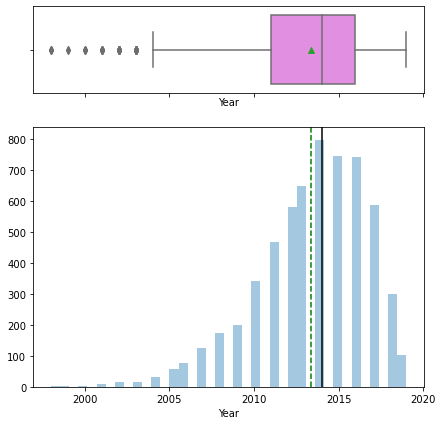

```python
histogram_boxplot(df["Year"])
```

#### Observations:

1. Data for Year is left skewed with a couple of outliers on the much older side
2. 75% of the data is 2016 or older

### Univariate Analysis: Kilometers_Driven

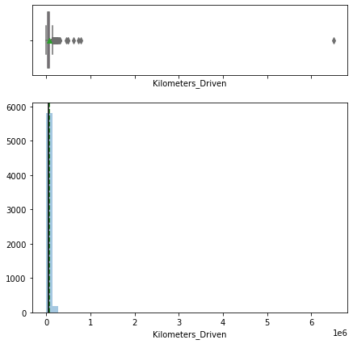

```python
histogram_boxplot(df["Kilometers_Driven"])
```

#### Data is extremely right-skewed. Let us try to do a log transformation here to make it look more like a normal distribution:

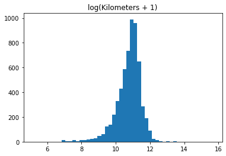

```python
plt.hist(np.log(df['Kilometers_Driven'] + 1), 50)
plt.title('log(Kilometers + 1)')
plt.show()
```

#### Let's look more into the outliers:

```python
quartiles = np.quantile(df['Kilometers_Driven'][df['Kilometers_Driven'].notnull()], [.25, .75])
power_4iqr = 4 * (quartiles[1] - quartiles[0])
print(f'Q1 = {quartiles[0]}, Q3 = {quartiles[1]}, 4*IQR = {power_4iqr}')
outlier_powers = df.loc[np.abs(df['Kilometers_Driven'] - df['Kilometers_Driven'].median()) > power_4iqr, 'Kilometers_Driven']
outlier_powers
```

```
Q1 = 34000.0, Q3 = 73000.0, 4*IQR = 156000.0
```

```
29       262000
77       230000
181      216000
340      775000
358      620000
838      215000
1068     225000
1101     248000
1442     231673
1528     299322
1766     220000
1846     255000
1860     720000
1975     282000
2267     215750
2328    6500000
2346     234000
2823     480000
2988     240000
3092     480000
3649     300000
3713     232000
3894     250000
4491     445000
4719     250000
4792     242000
5647     227000
5800     210000
5834     250000
Name: Kilometers_Driven, dtype: int64
```

#### Clearly, the datapoint on 2328 is completely an outlier. We will need to drop the following row:

```python
df.loc[[2328]]
```

|  | S.No. | Name | Location | Year | Kilometers_Driven | Fuel_Type | Transmission | Owner_Type | Mileage | Engine | Power | Seats | New_Price | Price |
| --- | --- | --- | --- | --- | --- | --- | --- | --- | --- | --- | --- | --- | --- | --- |
| 2328 | 2328 | BMW | Chennai | 2017 | 6500000 | Diesel | Automatic | First | 15.97 | 2993.0 | 258.0 | 5.0 | 11.415 | 65.0 |

```python
df = df.drop([2328])
```

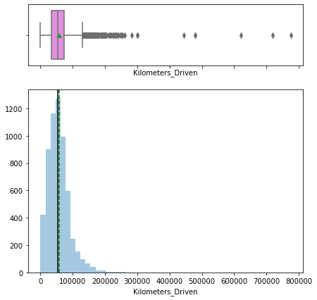

```python
histogram_boxplot(df["Kilometers_Driven"])
```

```python
outlier_powers = df.loc[np.abs(df['Kilometers_Driven'] - df['Kilometers_Driven'].median()) > power_4iqr, 'Kilometers_Driven']
outlier_powers.sort_values(ascending=True)
```

```
5800    210000
838     215000
2267    215750
181     216000
1766    220000
1068    225000
5647    227000
77      230000
1442    231673
3713    232000
2346    234000
2988    240000
4792    242000
1101    248000
3894    250000
4719    250000
5834    250000
1846    255000
29      262000
1975    282000
1528    299322
3649    300000
4491    445000
2823    480000
3092    480000
358     620000
1860    720000
340     775000
Name: Kilometers_Driven, dtype: int64
```

#### Observations:

1. Mean is ~57668.047 km
2. Outliers exist on the right side of the graph, ie. ranging from 210k-775k km
3. Min is 171 km, thus explaining the huge standard deviation.

```python
df.describe()
```

|  | S.No. | Year | Kilometers_Driven | Mileage | Engine | Power | Seats | New_Price | Price |
| --- | --- | --- | --- | --- | --- | --- | --- | --- | --- |
| count | 6018.000000 | 6018.000000 | 6018.000000 | 6018.000000 | 6018.000000 | 6018.000000 | 6018.000000 | 6018.000000 | 6018.000000 |
| mean | 3009.113161 | 2013.357594 | 57668.047690 | 18.135326 | 1620.281157 | 111.092409 | 5.276836 | 12.634393 | 9.470243 |
| std | 1737.802179 | 3.269677 | 37878.783175 | 4.581823 | 599.424157 | 55.285415 | 0.806405 | 8.073114 | 11.165926 |
| min | 0.000000 | 1998.000000 | 171.000000 | 0.000000 | 72.000000 | 0.000000 | 0.000000 | 1.000000 | 0.440000 |
| 25% | 1504.250000 | 2011.000000 | 34000.000000 | 15.170000 | 1198.000000 | 74.000000 | 5.000000 | 11.415000 | 3.500000 |
| 50% | 3009.500000 | 2014.000000 | 53000.000000 | 18.150000 | 1493.000000 | 92.700000 | 5.000000 | 11.415000 | 5.640000 |
| 75% | 4513.750000 | 2016.000000 | 73000.000000 | 21.100000 | 1969.000000 | 138.030000 | 5.000000 | 11.415000 | 9.950000 |
| max | 6018.000000 | 2019.000000 | 775000.000000 | 33.540000 | 5998.000000 | 560.000000 | 10.000000 | 99.920000 | 160.000000 |

### Univariate Analysis: Mileage

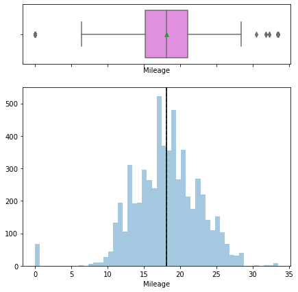

```python
histogram_boxplot(df["Mileage"])
```

#### Observations:

1. Data is almost a normal distribution.
2. Some outliers exist, but not that many.
3. Mean is 18

### Univariate Analysis: Engine displacement volume

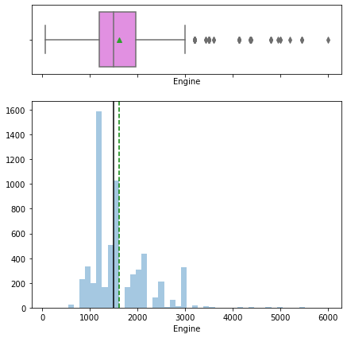

```python
histogram_boxplot(df["Engine"])
```

```python
df['Engine'].value_counts(dropna=False)
```

```
1197.0    606
1248.0    512
1498.0    304
998.0     259
2179.0    240
         ...
2149.0      1
3197.0      1
2694.0      1
970.0       1
2999.0      1
Name: Engine, Length: 146, dtype: int64
```

#### Observations:

1. Data is right-skewed, but appears almost random.
2. The highest number of engines are 1197 CC and 1248 CC.

### Univariate Analysis: Power

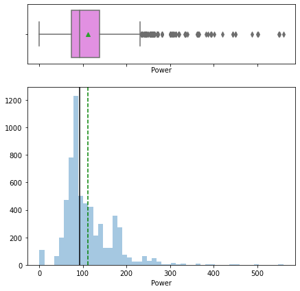

```python
histogram_boxplot(df["Power"])
```

#### Observations:

1. Right-skewed
2. Bulk of data is between 0 to ~250.
3. Many outliers above 250

### Univariate Analysis: Seats

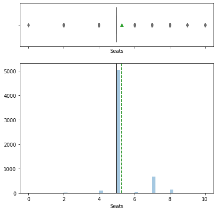

```python
histogram_boxplot(df["Seats"])
```

#### Observations:

It was fairly obvious that the boxplot wouldn't help us here as we are only interested in discrete values, ie mode. "Average" numbers of seats does not help us. We can see that the mode of seats is 5, i.e. most cars are 5-seaters. Let's check what the median is as, well:

```python
df['Seats'].median(axis = 0, skipna = True)
```

```
5.0
```

### Univariate Analysis: New_Price

#### We will only use New_Price as a comparison tool for Price in bivariate analysis

```python
#### Let's take a look once at all the histograms and box plots to summarize
```

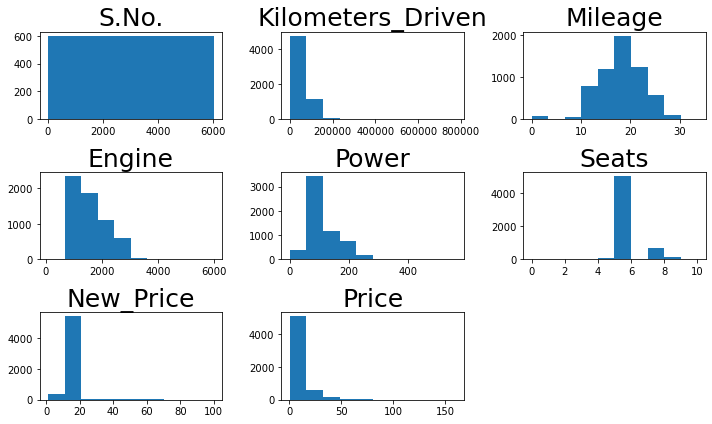

```python
# let's plot histogram of all variables
from scipy.stats import norm
all_col = df.select_dtypes(include=np.number).columns.tolist()
all_col.remove('Year')
plt.figure(figsize=(10,35))

for i in range(len(all_col)):
    plt.subplot(18,3,i+1)
    plt.hist(df[all_col[i]])
    #sns.displot(df[all_col[i]], kde=True)
    plt.tight_layout()
    plt.title(all_col[i],fontsize=25)


plt.show()
```

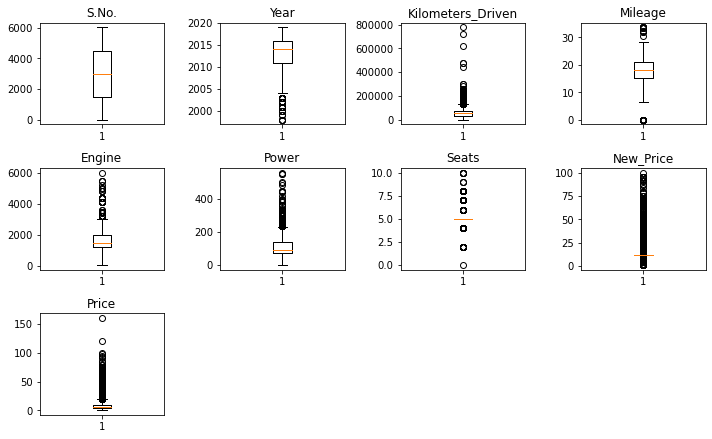

```python
# outlier detection using boxplot
plt.figure(figsize=(10,10))

for i, variable in enumerate(numeric_columns):
                     plt.subplot(5,4,i+1)
                     plt.boxplot(df[variable],whis=1.5)
                     plt.tight_layout()
                     plt.title(variable)

plt.show()
```

## Section 7a: EDA: Bivariate Analysis - Numerical Data

First off, let's take a look at a heatmap focusing on the Price (Dependent) variable's correlation with the other variables.

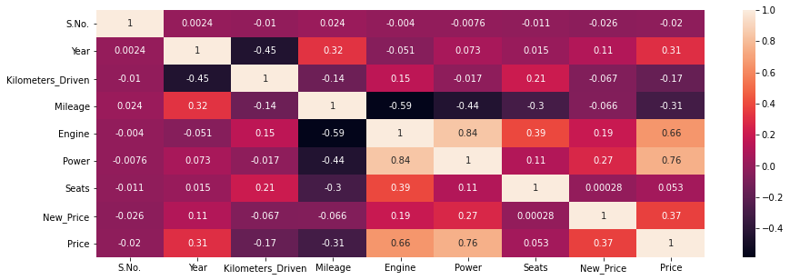

```python
plt.figure(figsize=(15,5))
sns.heatmap(df.corr(),annot=True)
plt.show()
```

#### Observations:

1. Power and Price have a high positive correlation. Higher power has a higher price.
2. Engine and Price also have a high positive correlation. Higher Engine CC has a higher price.
3. It's quite interesting that the New_Price doesn't correlate with the Price; we will observe this later to see how the two may compare

#### Continuous Variable Scatterplots:

```python
df.head()
```

|  | S.No. | Name | Location | Year | Kilometers_Driven | Fuel_Type | Transmission | Owner_Type | Mileage | Engine | Power | Seats | New_Price | Price |
| --- | --- | --- | --- | --- | --- | --- | --- | --- | --- | --- | --- | --- | --- | --- |
| 0 | 0 | Maruti | Mumbai | 2010 | 72000 | CNG | Manual | First | 26.60 | 998.0 | 58.16 | 5.0 | 11.415 | 1.75 |
| 1 | 1 | Hyundai | Pune | 2015 | 41000 | Diesel | Manual | First | 19.67 | 1582.0 | 126.20 | 5.0 | 11.415 | 12.50 |
| 2 | 2 | Honda | Chennai | 2011 | 46000 | Petrol | Manual | First | 18.20 | 1199.0 | 88.70 | 5.0 | 8.610 | 4.50 |
| 3 | 3 | Maruti | Chennai | 2012 | 87000 | Diesel | Manual | First | 20.77 | 1248.0 | 88.76 | 7.0 | 11.415 | 6.00 |
| 4 | 4 | Audi | Coimbatore | 2013 | 40670 | Diesel | Automatic | Second | 15.20 | 1968.0 | 140.80 | 5.0 | 11.415 | 17.74 |

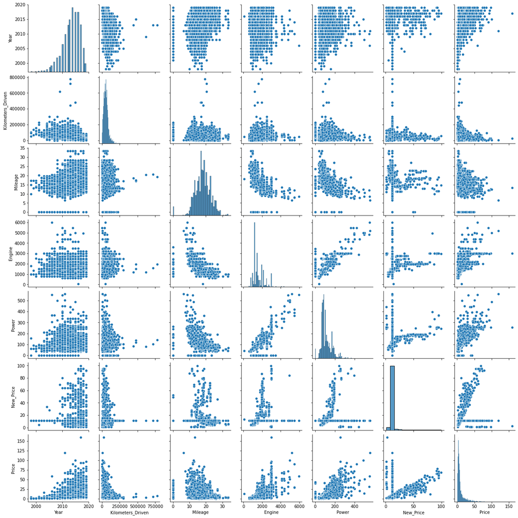

```python
sns.pairplot(data=df.drop(["S.No.","Seats","Name","Location","Fuel_Type","Owner_Type","Transmission"],axis=1))
```

#### As we expected, we see that a higher power and higher engine results in higher price.

#### Interestingly; Visually, we do see a correlation between New_Price and Price, but this did not show up in the correlation heatmap as there are discrete values inside New_Price:

```python
df['New_Price'].value_counts(dropna=False).sort_values(ascending=False)
```

```
11.415    5194
63.710       6
4.780        6
95.130       6
4.980        5
          ...
13.720       1
7.540        1
24.020       1
95.380       1
10.990       1
Name: New_Price, Length: 541, dtype: int64
```

```python
df['New_Price'].count
```

```
<bound method Series.count of 0       11.415
1       11.415
2        8.610
3       11.415
4       11.415
         ...
6014     7.880
6015    11.415
6016    11.415
6017    11.415
6018    11.415
Name: New_Price, Length: 6018, dtype: float64>
```

#### It appears that there are a high number of prices set at 11.415 Lakhs in addition to a few outliers. It would be interesting to see the correlation if we took these out of the dataset.

```python
df_price = df.copy()
df_price.head()
```

|  | S.No. | Name | Location | Year | Kilometers_Driven | Fuel_Type | Transmission | Owner_Type | Mileage | Engine | Power | Seats | New_Price | Price |
| --- | --- | --- | --- | --- | --- | --- | --- | --- | --- | --- | --- | --- | --- | --- |
| 0 | 0 | Maruti | Mumbai | 2010 | 72000 | CNG | Manual | First | 26.60 | 998.0 | 58.16 | 5.0 | 11.415 | 1.75 |
| 1 | 1 | Hyundai | Pune | 2015 | 41000 | Diesel | Manual | First | 19.67 | 1582.0 | 126.20 | 5.0 | 11.415 | 12.50 |
| 2 | 2 | Honda | Chennai | 2011 | 46000 | Petrol | Manual | First | 18.20 | 1199.0 | 88.70 | 5.0 | 8.610 | 4.50 |
| 3 | 3 | Maruti | Chennai | 2012 | 87000 | Diesel | Manual | First | 20.77 | 1248.0 | 88.76 | 7.0 | 11.415 | 6.00 |
| 4 | 4 | Audi | Coimbatore | 2013 | 40670 | Diesel | Automatic | Second | 15.20 | 1968.0 | 140.80 | 5.0 | 11.415 | 17.74 |

```python
#create a new dataframe to simplify

df_price.drop(['S.No.'],axis=1, inplace=True)
#df_price.drop(['Name'],axis=1, inplace=True)
df_price.drop(['Location'],axis=1, inplace=True)
df_price.drop(['Year'],axis=1, inplace=True)
df_price.drop(['Kilometers_Driven'],axis=1, inplace=True)
df_price.drop(['Fuel_Type'],axis=1, inplace=True)
df_price.drop(['Transmission'],axis=1, inplace=True)
df_price.drop(['Owner_Type'],axis=1, inplace=True)
df_price.drop(['Mileage'],axis=1, inplace=True)
df_price.drop(['Engine'],axis=1, inplace=True)
df_price.drop(['Power'],axis=1, inplace=True)
df_price.drop(['Seats'],axis=1, inplace=True)
df_price.head()
```

|  | Name | New_Price | Price |
| --- | --- | --- | --- |
| 0 | Maruti | 11.415 | 1.75 |
| 1 | Hyundai | 11.415 | 12.50 |
| 2 | Honda | 8.610 | 4.50 |
| 3 | Maruti | 11.415 | 6.00 |
| 4 | Audi | 11.415 | 17.74 |

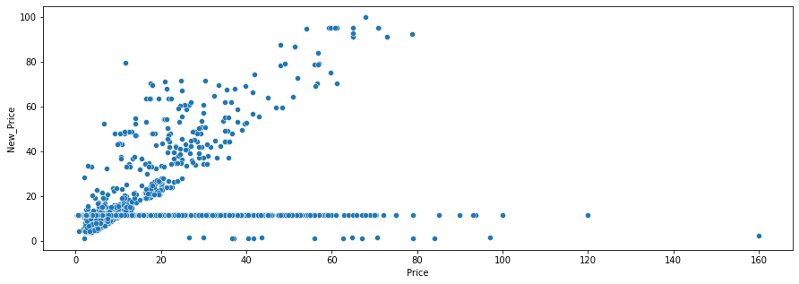

```python
figure = plt.figure(figsize=(15,5))

ax = sns.scatterplot(x=df['Price'],y=df['New_Price'], data=df_price) # scatter plot
```

```python
df_price.corr()
```

|  | New_Price | Price |
| --- | --- | --- |
| New_Price | 1.000000 | 0.369016 |
| Price | 0.369016 | 1.000000 |

#### As above, correlation was 0.37 for New_Price vs Price, ie implying that New_Price can't tell us much about Price. Now, let's take out the discrete value of 11.415 lakhs and see if the correlation can get better:

```python
df_price['New_Price'].value_counts(dropna=False).sort_values(ascending=False)
```

```
11.415    5194
63.710       6
4.780        6
95.130       6
4.980        5
          ...
13.720       1
7.540        1
24.020       1
95.380       1
10.990       1
Name: New_Price, Length: 541, dtype: int64
```

```python
df_price = df_price[df_price['New_Price'] != 11.415]
df_price['New_Price'].value_counts(dropna=False).sort_values(ascending=False)
```

```
63.71    6
95.13    6
4.78     6
44.28    5
47.87    5
        ..
4.80     1
17.21    1
69.47    1
3.98     1
7.46     1
Name: New_Price, Length: 540, dtype: int64
```

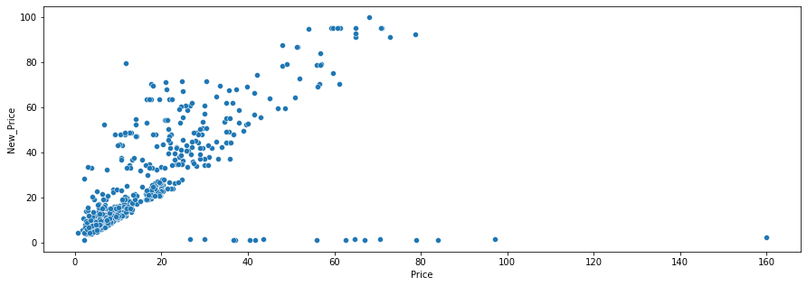

```python
figure = plt.figure(figsize=(15,5))

ax = sns.scatterplot(x=df_price['Price'],y=df_price['New_Price'], data=df_price) # scatter plot
```

```python
df_price.corr()
```

|  | New_Price | Price |
| --- | --- | --- |
| New_Price | 1.000000 | 0.686588 |
| Price | 0.686588 | 1.000000 |

#### The correlation increased from 0.37 to 0.69! So, therefore we can depend on the New_Price column in the investigation going further.

## Section 7: EDA: Bivariate Analysis - Categorical Data

```python
df.head()
```

|  | S.No. | Name | Location | Year | Kilometers_Driven | Fuel_Type | Transmission | Owner_Type | Mileage | Engine | Power | Seats | New_Price | Price |
| --- | --- | --- | --- | --- | --- | --- | --- | --- | --- | --- | --- | --- | --- | --- |
| 0 | 0 | Maruti | Mumbai | 2010 | 72000 | CNG | Manual | First | 26.60 | 998.0 | 58.16 | 5.0 | 11.415 | 1.75 |
| 1 | 1 | Hyundai | Pune | 2015 | 41000 | Diesel | Manual | First | 19.67 | 1582.0 | 126.20 | 5.0 | 11.415 | 12.50 |
| 2 | 2 | Honda | Chennai | 2011 | 46000 | Petrol | Manual | First | 18.20 | 1199.0 | 88.70 | 5.0 | 8.610 | 4.50 |
| 3 | 3 | Maruti | Chennai | 2012 | 87000 | Diesel | Manual | First | 20.77 | 1248.0 | 88.76 | 7.0 | 11.415 | 6.00 |
| 4 | 4 | Audi | Coimbatore | 2013 | 40670 | Diesel | Automatic | Second | 15.20 | 1968.0 | 140.80 | 5.0 | 11.415 | 17.74 |

#### Let us begin our bivariate analysis on how Name, Location, Fuel_Type, Transmission, and Owner_Type affects Price

### Name Vs Price

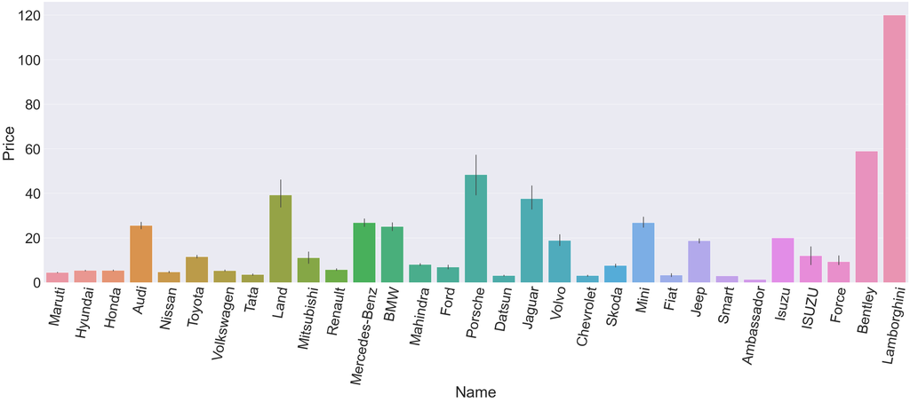

```python
fig_dims = (60, 20)
fig, ax = plt.subplots(figsize=fig_dims)
g = sns.barplot(df['Name'],df['Price'], ax=ax, data=df)
sns.set(font_scale=5)
plt.setp(g.get_xticklabels(), rotation=80);
```

#### Lamborghini clearly takes the cake for having a higher price. Bentley, Porche, Land, and Jaguar clearly follow after. Would be interesting to check this with New_Price, as well:

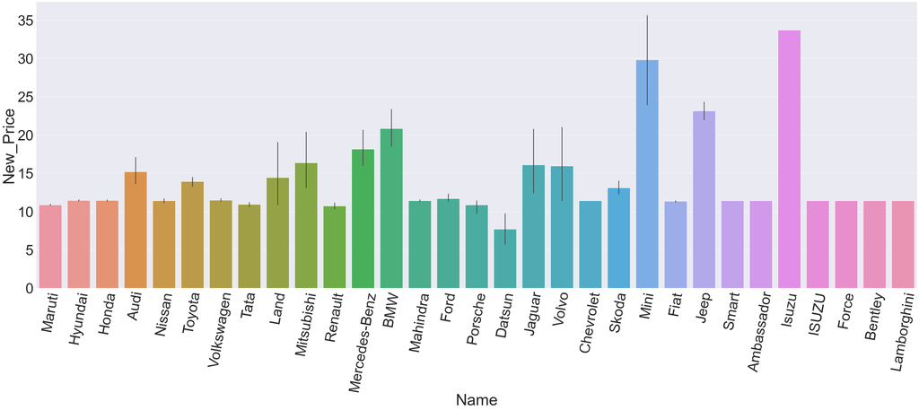

```python
fig_dims = (60, 20)
fig, ax = plt.subplots(figsize=fig_dims)
g = sns.barplot(df['Name'],df['New_Price'], ax=ax, data=df)
sns.set(font_scale=5)
plt.setp(g.get_xticklabels(), rotation=80);
```

#### It's clear from the barplot that some of the bigger names have set pricing, which were the discrete horizontal lines we saw in the scatter plot. This is a good guideline for pricing new cars, as we wouldn't want the pricing of the used car to exceed that of the new cars.

### Location vs Price

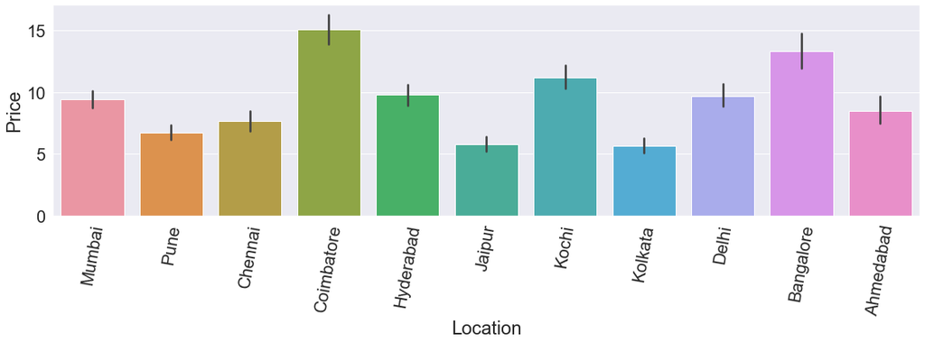

```python
fig_dims = (20, 5)
fig, ax = plt.subplots(figsize=fig_dims)
g = sns.barplot(df['Location'],df['Price'], ax=ax, data=df)
sns.set(font_scale=2)
plt.setp(g.get_xticklabels(), rotation=80);
```

#### Cars in Coimbatore, Bangalore, and Kochi are priced highest for used cars. Let's check the same with new cars:

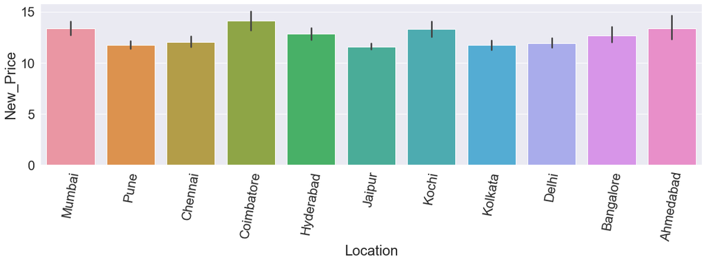

```python
fig_dims = (20, 5)
fig, ax = plt.subplots(figsize=fig_dims)
g = sns.barplot(df['Location'],df['New_Price'], ax=ax, data=df)
sns.set(font_scale=2)
plt.setp(g.get_xticklabels(), rotation=80);
```

```python
### Fuel_Type vs Price
```

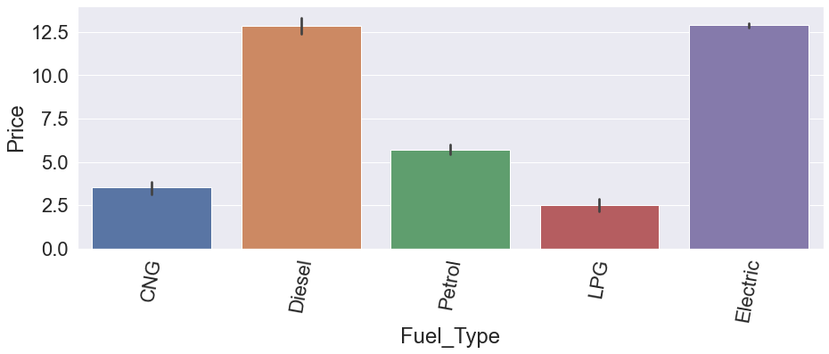

```python
fig_dims = (15, 5)
fig, ax = plt.subplots(figsize=fig_dims)
g = sns.barplot(df['Fuel_Type'],df['Price'], ax=ax, data=df)
sns.set(font_scale=2)
plt.setp(g.get_xticklabels(), rotation=80);
```

#### LPG is priced lowest, and Diesel/Electric are priced highest for used cars. Let's see if it makes a difference for newer cars:

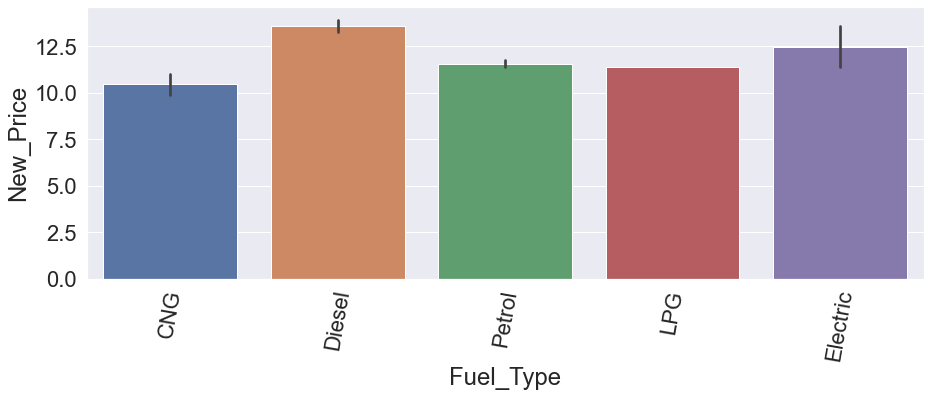

```python
fig_dims = (15, 5)
fig, ax = plt.subplots(figsize=fig_dims)
g = sns.barplot(df['Fuel_Type'],df['New_Price'], ax=ax, data=df)
sns.set(font_scale=2)
plt.setp(g.get_xticklabels(), rotation=80);
```

#### While CNG, Petrol, and LPG cars are still cheaper than Diesel and Electric cars, there isn't as huge of difference in pricing in the case of new cars. That, therefore, is a clear advantage of buying used cars.

### Transmission Vs Price

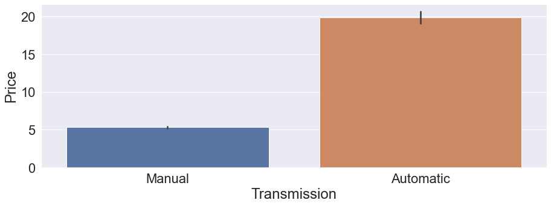

```python
fig_dims = (15, 5)
fig, ax = plt.subplots(figsize=fig_dims)
sns.barplot(df['Transmission'],df['Price'], ax=ax, data=df)
sns.set(font_scale=2)
#plt.setp(g.get_xticklabels(), rotation=80);
```

#### Automatic cars are priced much higher than manual cars. Looking at new cars, the same pattern exists, but interestingly used automatic cars are priced higher than new automatic cars.

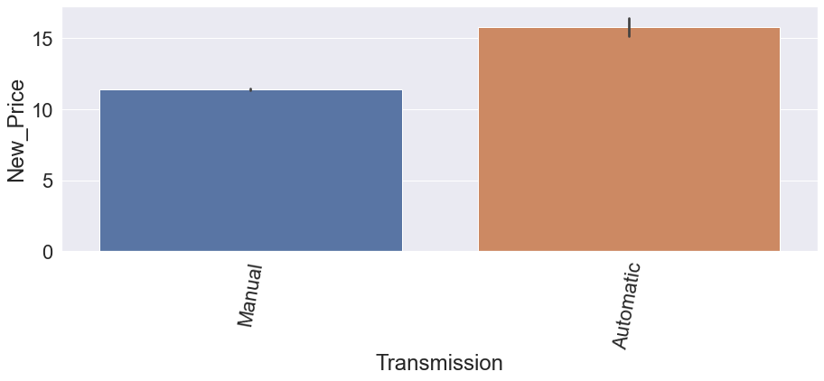

```python
fig_dims = (15, 5)
fig, ax = plt.subplots(figsize=fig_dims)
g = sns.barplot(df['Transmission'],df['New_Price'], ax=ax, data=df)
sns.set(font_scale=2)
plt.setp(g.get_xticklabels(), rotation=80);
```

#### It seems that some of the luxury cars have a completely standard price which is what we took out. We can confirm this by plotting Name and New_Price from the modified dataset to see which ones disappeared when we took the price out of the dataset that was lowering the correlation coefficient.

### Owner_Type vs Price

```python
sns.set(font_scale=1.5)
```

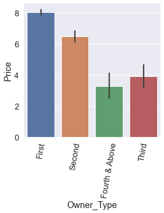

```python
fig_dims = (5, 5)
fig, ax = plt.subplots(figsize=fig_dims)
g = sns.barplot(df['Owner_Type'],df['Price'], ax=ax, data=df)

plt.setp(g.get_xticklabels(), rotation=80);
```

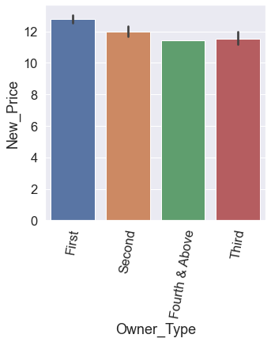

```python
fig_dims = (5, 5)
fig, ax = plt.subplots(figsize=fig_dims)
g = sns.barplot(df['Owner_Type'],df['New_Price'], ax=ax, data=df)

plt.setp(g.get_xticklabels(), rotation=80);
```

## Section 9: Model-Building Prep

### Outlier Handling

#### Lets treat outliers by flooring and capping.

```python
def treat_outliers(df,col):
    '''
    treats outliers in a variable
    col: str, name of the numerical variable
    df: data frame
    col: name of the column
    '''
    Q1=df[col].quantile(0.25) # 25th quantile
    Q3=df[col].quantile(0.75)  # 75th quantile
    IQR=Q3-Q1
    Lower_Whisker = Q1 - 1.5*IQR
    Upper_Whisker = Q3 + 1.5*IQR
    df[col] = np.clip(df[col], Lower_Whisker, Upper_Whisker) # all the values samller than Lower_Whisker will be assigned value of Lower_whisker
                                                            # and all the values above upper_whishker will be assigned value of upper_Whisker
    return df

def treat_outliers_all(df, col_list):
    '''
    treat outlier in all numerical variables
    col_list: list of numerical variables
    df: data frame
    '''
    for c in col_list:
        df = treat_outliers(df,c)

    return df
```

```python
numerical_col = df.select_dtypes(include=np.number).columns.tolist()
df = treat_outliers_all(df,numerical_col)
```

#### Now that this has all been converted, let's look at box plots to see if outliers has been treated or not.

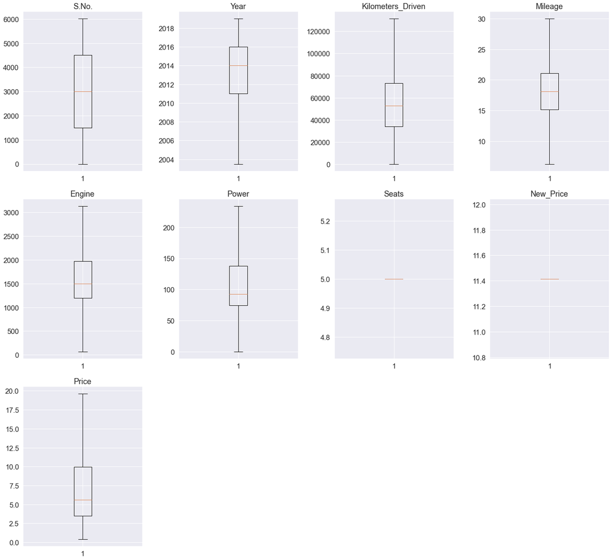

```python
plt.figure(figsize=(20,30))

for i, variable in enumerate(numeric_columns):
                     plt.subplot(5,4,i+1)
                     plt.boxplot(df[variable],whis=1.5)
                     plt.tight_layout()
                     plt.title(variable)

plt.show()
```

### Dummy Variables for Categorical Variables

#### The last preparation here before model-building is converting the categorial variables into discrete values. We will do this by first defining the data in form of what we'll need for the model and setting up dummies:

```python
#Defining X and y variables
X = df.drop(['Price'], axis=1)
y = df[['Price']]

print(X.head())
print(y.head())
```

```
   S.No.     Name    Location    Year  Kilometers_Driven Fuel_Type  \
0      0   Maruti      Mumbai  2010.0              72000       CNG
1      1  Hyundai        Pune  2015.0              41000    Diesel
2      2    Honda     Chennai  2011.0              46000    Petrol
3      3   Maruti     Chennai  2012.0              87000    Diesel
4      4     Audi  Coimbatore  2013.0              40670    Diesel

  Transmission Owner_Type  Mileage  Engine   Power  Seats  New_Price
0       Manual      First    26.60   998.0   58.16    5.0     11.415
1       Manual      First    19.67  1582.0  126.20    5.0     11.415
2       Manual      First    18.20  1199.0   88.70    5.0     11.415
3       Manual      First    20.77  1248.0   88.76    5.0     11.415
4    Automatic     Second    15.20  1968.0  140.80    5.0     11.415
   Price
0   1.75
1  12.50
2   4.50
3   6.00
4  17.74
```

```python
print(X.shape)
print(y.shape)
```

```
(6018, 13)
(6018, 1)
```

```python
X = pd.get_dummies(X, columns=['Name', 'Location', 'Fuel_Type','Transmission','Owner_Type'], drop_first=True)
X.head()
```

|  | S.No. | Year | Kilometers_Driven | Mileage | Engine | Power | Seats | New_Price | Name_Audi | Name_BMW | ... | Location_Mumbai | Location_Pune | Fuel_Type_Diesel | Fuel_Type_Electric | Fuel_Type_LPG | Fuel_Type_Petrol | Transmission_Manual | Owner_Type_Fourth & Above | Owner_Type_Second | Owner_Type_Third |
| --- | --- | --- | --- | --- | --- | --- | --- | --- | --- | --- | --- | --- | --- | --- | --- | --- | --- | --- | --- | --- | --- |
| 0 | 0 | 2010.0 | 72000 | 26.60 | 998.0 | 58.16 | 5.0 | 11.415 | 0 | 0 | ... | 1 | 0 | 0 | 0 | 0 | 0 | 1 | 0 | 0 | 0 |
| 1 | 1 | 2015.0 | 41000 | 19.67 | 1582.0 | 126.20 | 5.0 | 11.415 | 0 | 0 | ... | 0 | 1 | 1 | 0 | 0 | 0 | 1 | 0 | 0 | 0 |
| 2 | 2 | 2011.0 | 46000 | 18.20 | 1199.0 | 88.70 | 5.0 | 11.415 | 0 | 0 | ... | 0 | 0 | 0 | 0 | 0 | 1 | 1 | 0 | 0 | 0 |
| 3 | 3 | 2012.0 | 87000 | 20.77 | 1248.0 | 88.76 | 5.0 | 11.415 | 0 | 0 | ... | 0 | 0 | 1 | 0 | 0 | 0 | 1 | 0 | 0 | 0 |
| 4 | 4 | 2013.0 | 40670 | 15.20 | 1968.0 | 140.80 | 5.0 | 11.415 | 1 | 0 | ... | 0 | 0 | 1 | 0 | 0 | 0 | 0 | 0 | 1 | 0 |

5 rows × 56 columns

## Section 10: Model-Building

#### Now that everything is all set, we can actually set up the model

```python
#split the data into train and test
from sklearn.model_selection import train_test_split
X_train, X_test, y_train, y_test = train_test_split(X, y, test_size=0.3, random_state=42)
```

```python
X_train.head()
```

|  | S.No. | Year | Kilometers_Driven | Mileage | Engine | Power | Seats | New_Price | Name_Audi | Name_BMW | ... | Location_Mumbai | Location_Pune | Fuel_Type_Diesel | Fuel_Type_Electric | Fuel_Type_LPG | Fuel_Type_Petrol | Transmission_Manual | Owner_Type_Fourth & Above | Owner_Type_Second | Owner_Type_Third |
| --- | --- | --- | --- | --- | --- | --- | --- | --- | --- | --- | --- | --- | --- | --- | --- | --- | --- | --- | --- | --- | --- |
| 841 | 841 | 2014.0 | 84000 | 19.30 | 1968.0 | 141.0 | 5.0 | 11.415 | 0 | 0 | ... | 1 | 0 | 1 | 0 | 0 | 0 | 0 | 0 | 0 | 0 |
| 3379 | 3379 | 2012.0 | 97000 | 20.45 | 1461.0 | 83.8 | 5.0 | 11.415 | 0 | 0 | ... | 0 | 0 | 1 | 0 | 0 | 0 | 1 | 0 | 1 | 0 |
| 1189 | 1189 | 2014.0 | 30000 | 16.80 | 1497.0 | 116.3 | 5.0 | 11.415 | 0 | 0 | ... | 0 | 0 | 0 | 0 | 0 | 1 | 1 | 0 | 1 | 0 |
| 175 | 175 | 2013.0 | 21000 | 14.40 | 1598.0 | 103.6 | 5.0 | 11.415 | 0 | 0 | ... | 1 | 0 | 0 | 0 | 0 | 1 | 0 | 0 | 1 | 0 |
| 4748 | 4748 | 2019.0 | 16698 | 23.84 | 1199.0 | 84.0 | 5.0 | 11.415 | 0 | 0 | ... | 0 | 0 | 0 | 0 | 0 | 1 | 1 | 0 | 0 | 0 |

5 rows × 56 columns

### Choose Model, Train, and Evaluate

```python
#Fitting linear model
lin_reg_model = LinearRegression()
lin_reg_model.fit(X_train, y_train)
```

```
LinearRegression()
```

```python
# let us check the coefficients and intercept of the model

coef_df = pd.DataFrame(np.append(lin_reg_model.coef_.flatten(), lin_reg_model.intercept_), \
                       index=X_train.columns.tolist()+['Intercept'], columns=['Coefficients'])
print(coef_df)
```

```
                           Coefficients
S.No.                      9.082947e-06
Year                       5.720916e-01
Kilometers_Driven         -1.383006e-05
Mileage                   -1.818351e-01
Engine                     1.162963e-03
Power                      2.655880e-02
Seats                     -1.033384e-10
New_Price                  4.708363e-10
Name_Audi                  3.555440e+00
Name_BMW                   3.001063e+00
Name_Bentley               7.259276e+00
Name_Chevrolet            -3.531613e+00
Name_Datsun               -4.143518e+00
Name_Fiat                 -3.366300e+00
Name_Force                -2.673719e+00
Name_Ford                 -2.646143e+00
Name_Honda                -2.477904e+00
Name_Hyundai              -2.314561e+00
Name_ISUZU                -3.566792e+00
Name_Isuzu                -5.222178e-11
Name_Jaguar                3.572887e+00
Name_Jeep                  3.632671e+00
Name_Lamborghini           4.864410e+00
Name_Land                  4.238026e+00
Name_Mahindra             -3.279407e+00
Name_Maruti               -2.013496e+00
Name_Mercedes-Benz         2.663500e+00
Name_Mini                  7.078003e+00
Name_Mitsubishi           -1.037810e+00
Name_Nissan               -3.024837e+00
Name_Porsche               2.749500e+00
Name_Renault              -3.029190e+00
Name_Skoda                -2.284115e+00
Name_Smart                -5.593748e-12
Name_Tata                 -3.946235e+00
Name_Toyota                1.264253e-01
Name_Volkswagen           -3.102090e+00
Name_Volvo                 3.696530e+00
Location_Bangalore         7.417327e-01
Location_Chennai           1.017863e-01
Location_Coimbatore        5.204266e-01
Location_Delhi            -5.373541e-01
Location_Hyderabad         5.601274e-01
Location_Jaipur            5.434139e-02
Location_Kochi            -1.668648e-01
Location_Kolkata          -1.319029e+00
Location_Mumbai           -3.610594e-01
Location_Pune             -1.753778e-01
Fuel_Type_Diesel           1.268438e+00
Fuel_Type_Electric         8.474478e+00
Fuel_Type_LPG             -3.158703e-01
Fuel_Type_Petrol          -6.295276e-01
Transmission_Manual       -1.223978e+00
Owner_Type_Fourth & Above -4.158551e-01
Owner_Type_Second         -3.297292e-01
Owner_Type_Third          -3.444570e-01
Intercept                 -1.142855e+03
```

```python
# MAPE
def mape(targets, predictions):
    return np.mean(np.abs((targets - predictions)) / targets) * 100

# Adjusted R^2
def adj_r2(ind_vars, targets, predictions):
    r2 = r2_score(targets, predictions)
    n = ind_vars.shape[0]
    k = ind_vars.shape[1]
    return 1-((1-r2)*(n-1)/(n-k-1))

# Model performance check
def model_perf(model, inp, out):

    y_pred = model.predict(inp)
    y_act = out.values

    return pd.DataFrame({
                "MAE": mean_absolute_error(y_act, y_pred),
                "MAPE": mape(y_act, y_pred),
                "RMSE": np.sqrt(mean_squared_error(y_act, y_pred)),
                "R^2": r2_score(y_act, y_pred),
                "Adjusted R^2": adj_r2(inp, y_act, y_pred)
           }, index=[0])
```

```python
# Checking model performance on train set
print('Training Performance\n')
print(model_perf(lin_reg_model, X_train, y_train))
```

```
Training Performance

        MAE       MAPE     RMSE       R^2  Adjusted R^2
0  1.362068  29.420459  1.86426  0.895429       0.89402
```

```python
# Checking model performance on test set
print('Test Performance\n')
print(model_perf(lin_reg_model, X_test, y_test))
```

```
Test Performance

        MAE       MAPE      RMSE       R^2  Adjusted R^2
0  1.400508  30.820805  1.920431  0.889381       0.88584
```